# Project_RMark_Ver2

Frayosh Khursetjee

5 March 2017

### Understanding the Data

The Dependent Variable is a Categorical Variable and the remainder variables are a combination of continuous and Categorical variables. 40% of the Variables are populated with Blank values hence they were all removed.

```r
library(ggplot2)
library(rpart)
library(rpart.plot)
library(caret)
library(randomForest)
library(dplyr)
```

```r
pml.training <- read.csv("//inmbfp1/redirect1/g551739/My Documents/R_Code/Machine_Learning/pml-training.csv", stringsAsFactors=FALSE)
dim(pml.training)
```

```
## [1] 19622    59
```

```r
pml.testing <- read.csv("//inmbfp1/redirect1/g551739/My Documents/R_Code/Machine_Learning/pml-testing.csv", stringsAsFactors=FALSE)
```

### Pre-Processing and drawing nuances

Ho (Null Hypothesis): Considered Categorical Variables are independent.

Ha (Alternate Hypothesis): Considered Categorical Variables are in some way dependent

```r
klm <- table(pml.training$user_name, pml.training$classe)
chisq.test(klm)
```

```
##
##  Pearson's Chi-squared test
##
## data:  klm
## X-squared = 242.52, df = 20, p-value < 2.2e-16
```

Checking for One Sided Data & Removing unnecesary Variables New Window & Time Stamp Variables

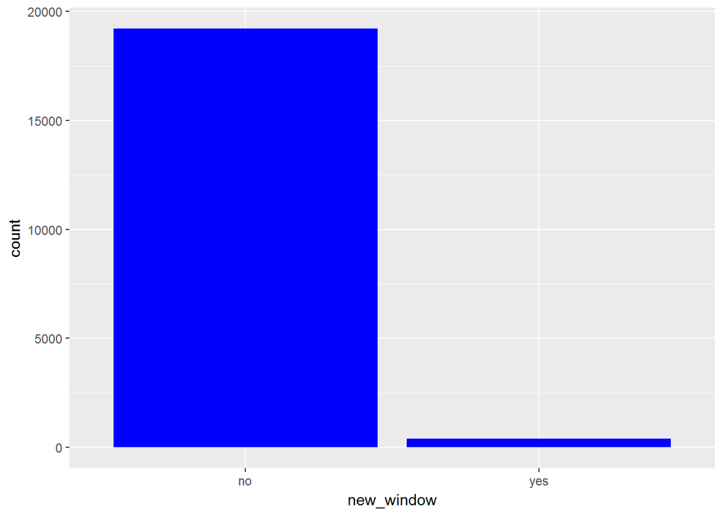

```r
train <- pml.training
train <- select(pml.training, -c(2,3,4,5))
ggplot(pml.training,aes(x=new_window)) + geom_bar(fill = "blue")
```

Checking for Multicollinearity and removing correlated variables

```r
M <- abs(cor(train[,-c(1,55)]))
diag(M) <- 0
ll <- as.data.frame(which(M > 0.9,arr.ind=T))
rownames(ll)
```

```
##  [1] "total_accel_belt" "accel_belt_y"     "accel_belt_z"
##  [4] "accel_belt_x"     "roll_belt"        "accel_belt_y"
##  [7] "accel_belt_z"     "pitch_belt"       "roll_belt"
## [10] "total_accel_belt" "accel_belt_z"     "roll_belt"
## [13] "total_accel_belt" "accel_belt_y"     "gyros_arm_y"
## [16] "gyros_arm_x"      "gyros_dumbbell_z" "gyros_forearm_z"
## [19] "gyros_dumbbell_x" "gyros_forearm_z"  "gyros_dumbbell_x"
## [22] "gyros_dumbbell_z"
```

```r
train <- select(train, -c(roll_belt,pitch_belt,accel_belt_y,gyros_arm_x,accel_belt_z,gyros_dumbbell_x, gyros_dumbbell_z, magnet_belt_x, magnet_arm_x, magnet_arm_z, gyros_forearm_z,accel_dumbbell_z,accel_dumbbell_x))
```

### Selecting the Model

Since we are predicting Categorical values and not continuous variables at a point in time, time-series modelling is out of the question. For Categorical Variable Predicting the best bet would be a CART model using the rpart Package and Random Forest.

We first Generate a CART Model using K-fold Validation with 5 Buckets. For a better analysis we have pre-processed the Data. i.e., subtract by the mean and dividing by the Standard Deviation

```r
control <- trainControl(method = "cv", number = 5)
rpart_model <- train(classe ~ ., data = train, method = "rpart", trControl = control, preProcess = c("center","scale"))
rpart_model
```

```
## CART
##
## 19622 samples
##    41 predictor
##     5 classes: 'A', 'B', 'C', 'D', 'E'
##
## Pre-processing: centered (45), scaled (45)
## Resampling: Cross-Validated (5 fold)
## Summary of sample sizes: 15697, 15699, 15698, 15698, 15696
## Resampling results across tuning parameters:
##
##   cp          Accuracy   Kappa
##   0.03240279  0.5496842  0.4290862
##   0.03884774  0.5087633  0.3691837
##   0.06612306  0.4322339  0.2447017
##
## Accuracy was used to select the optimal model using  the largest value.
## The final value used for the model was cp = 0.03240279.
```

Due to limited accuracy on the CART Model we shift to the Random Forest. Basically making mutiple Regression trees till we get a reduced error on one.

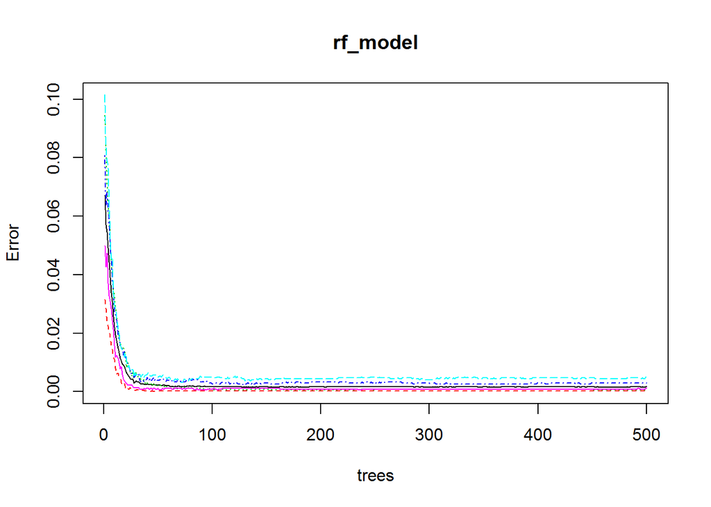

```r
train$classe = as.factor(train$classe)
train$user_name = as.factor(train$user_name)
rf_model <- randomForest(classe ~ ., data = train)
plot(rf_model)
```

Predicting on the given test set

```r
test <- pml.testing
test <- select(pml.testing, -c(2,3,4,5))
test <- select(test, -c(roll_belt,pitch_belt,accel_belt_y,gyros_arm_x,accel_belt_z,gyros_dumbbell_x, gyros_dumbbell_z, magnet_belt_x, magnet_arm_x, magnet_arm_z, gyros_forearm_z,accel_dumbbell_z,accel_dumbbell_x))
test$user_name = as.factor(test$user_name)
predict(rf_model,test)
```

```
##  1  2  3  4  5  6  7  8  9 10 11 12 13 14 15 16 17 18 19 20
##  B  A  B  A  A  E  D  B  A  A  B  C  B  A  E  E  A  B  B  B
## Levels: A B C D E
```